# Jupyter_Intro

## 11. Saving & Downloading a notebook

To save a notebook simply go to 'File' tab and select 'Save as'.

```python
uploaded = files.upload()
```

Upload widget is only available when the cell has been executed in the current browser session. Please rerun this cell to enable.

```
Saving save_as_1.png to save_as_1.png
```

[figure not shown]

```python
Image('save_as_1.png', width = 500)
```

A 'Save As' pop up window will open which will have the 'directory_name/notebook_name'. You can change 'notebook_name' the way you want. In the given example my directory_name is 'Jupyter_intro' & notebook_name is 'demo'. Once renamed click on 'save'. This will save your jupyter notebook as '.ipynb' extension.

```python
uploaded = files.upload()
```

Upload widget is only available when the cell has been executed in the current browser session. Please rerun this cell to enable.

```
Saving save_as_2.png to save_as_2.png
```

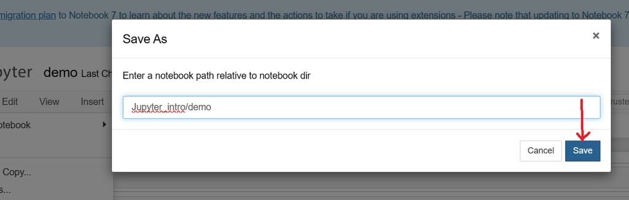

```python
Image('save_as_2.png', width = 800)
```

To download a notebook, go to 'File' tab and click on 'Download As'. To download it as a Jupyter notebook, further select Notebook (.ipynb).

```python
uploaded = files.upload()
```

Upload widget is only available when the cell has been executed in the current browser session. Please rerun this cell to enable.

```
Saving download_1.png to download_1.png
```

[figure not shown]

```python
Image('download_1.png', width = 500)
```

Once selected the notebook will be downloaded in your PC.

```python
uploaded = files.upload()
```

Upload widget is only available when the cell has been executed in the current browser session. Please rerun this cell to enable.

```
Saving download_2.png to download_2 (1).png
```

[figure not shown]

```python
Image('download_2.png', width = 800)
```

So all in all, I have taught you some basic features of the Jupyter UI. As you have seen yourself, there are plenty of options available apart from the one I taught. You can explore them in your free time.

But rest assured, I have only focused on features that are important for us to go ahead and do Python processing, Machine Learning & Deep Learning. We won't need any other features other than the one I mentioned above.

I hope you would be excited for your next session where we would start actual coding in Python. Until then, goodbye. :)